# R Notebook

We will first load data frames we used in Modules 1 and 2.

For PSON data:

```r
load(file.path(data_dir, "pson_expr_tpm_df.RData"))
load(file.path(data_dir, "pson_expr_gene_info.RData"))
```

For TCGA brca data:

```r
load(file.path(data_dir, "tcga_brca_expr_norm_df.RData"))
load(file.path(data_dir, "tcga_brca_clinical_df.RData"))
brca_expr_norm_df.orig <- brca_expr_norm_df
brca_clinical_df.orig <- brca_clinical_df
```

```r
x1 <- names(brca_expr_norm_df)[2:ncol(brca_expr_norm_df)]
x2 <- brca_clinical_df[["bcr_patient_barcode"]]
sample.names <- intersect(x1, x2)
sample.names <- sort(sample.names)
if(is.null(sample.names)) stop("No common samples")
if(length(sample.names) < 1000) stop("low number of common samples")
print(sample.names[1:10])
```

```
 [1] "TCGA-3C-AAAU" "TCGA-3C-AALI" "TCGA-3C-AALJ" "TCGA-3C-AALK" "TCGA-4H-AAAK" "TCGA-5L-AAT0"
 [7] "TCGA-5T-A9QA" "TCGA-A1-A0SB" "TCGA-A1-A0SD" "TCGA-A1-A0SE"
```

```r
I <- match(sample.names, names(brca_expr_norm_df))
if(any(is.na(I))) stop("Missing samples")
if(min(I) < 2) stop("missing gene id column")
I <- c(1, I)
brca_expr_norm_df <- brca_expr_norm_df[,I]
I <- match(sample.names, brca_clinical_df[["bcr_patient_barcode"]])
if(any(is.na(I))) stop("Missing samples")
brca_clinical_df <- brca_clinical_df[I,]
if(!all(sample.names == brca_clinical_df[["bcr_patient_barcode"]]))
  stop("Not aligned")
```

Notice how genes are identified. These are ensembl gene ids.

```r
brca_expr_norm_df[1:5,1:5]
```

|  | gene_id | TCGA-3C-AAAU | TCGA-3C-AALI | TCGA-3C-AALJ | TCGA-3C-AALK |
| --- | --- | --- | --- | --- | --- |
| 1 | ENSG00000215529 | 0.3447 | 4.8940 | 2.7199 | 2.0687 |
| 2 | ENSG00000178605 | 458.3960 | 683.5240 | 657.2980 | 786.5120 |
| 3 | ENSG00000172771 | 40.6697 | 29.9076 | 22.6655 | 54.1994 |
| 4 | ENSG00000121410 | 197.0900 | 237.3840 | 423.2370 | 191.0180 |
| 5 | ENSG00000148584 | 0.0000 | 0.0000 | 0.9066 | 0.0000 |

We convert the ensembl gene ids to hugo gene names.

```r
brca_expr_norm_df2<-merge(x=convert_ENSG_HUGO_df,y=brca_expr_norm_df, by.x="gene_id",by.y="gene_id")
brca_expr_norm_df2[1:5,1:5]
```

|  | gene_id | symbol | TCGA-3C-AAAU | TCGA-3C-AALI | TCGA-3C-AALJ |
| --- | --- | --- | --- | --- | --- |
| 1 | ENSG00000000003 | TSPAN6 | 188.1840 | 207.7220 | 1005.4400 |
| 2 | ENSG00000000005 | TNMD | 0.3447 | 1.0875 | 39.8912 |
| 3 | ENSG00000000419 | DPM1 | 524.2260 | 809.1350 | 967.3620 |
| 4 | ENSG00000000457 | SCYL3 | 325.1410 | 1558.9400 | 335.8300 |
| 5 | ENSG00000000460 | C1orf112 | 124.2940 | 274.6660 | 241.6860 |

We now have two columns for gene identification. We convert the data frame to a matrix for our calculations, and we repurpose the hugo gene names as the matix rownames.

```r
brca_expr_mat <- as.matrix(brca_expr_norm_df2[,3:ncol(brca_expr_norm_df2)])
rownames(brca_expr_mat) <- brca_expr_norm_df2$symbol
brca_expr_mat[1:5,1:5]
```

```
         TCGA-3C-AAAU TCGA-3C-AALI TCGA-3C-AALJ TCGA-3C-AALK TCGA-4H-AAAK
TSPAN6       188.1840     207.7220    1005.4400    1104.6800     942.5530
TNMD           0.3447       1.0875      39.8912       1.2412       4.6809
DPM1         524.2260     809.1350     967.3620     463.3840     486.3830
SCYL3        325.1410    1558.9400     335.8300     549.2550     416.2850
C1orf112     124.2940     274.6660     241.6860     218.2250     179.4600
```

We log2 transform the data and, as we did for the PCA analysis of the PSON data, take the transverse of the matrix so the samples are rows.

```r
brca_expr_log_mat<- log(brca_expr_mat+1, 2)
dim(brca_expr_log_mat)
```

```
[1] 18228  1083
```

```r
brca_mat<-t(brca_expr_log_mat)
dim(brca_mat)
```

```
[1]  1083 18228
```

Let’s also repeat the coloring function.

```r
csbc_Color=function(vec){

nn<-length(unique(vec))

csbc_cols=rainbow(nn,start=0,end=max(1,nn-1)/nn)

return(csbc_cols[as.numeric(as.factor(vec))])
}
```

Implementing the PCA algorithm in R is now straightforward.

```r
PCA_BRCA<-prcomp(brca_mat)
dim(PCA_BRCA$x)
```

```
[1] 1083 1083
```

```r
PCA_BRCA$x[1:5,1:5]
```

```
                   PC1       PC2        PC3        PC4         PC5
TCGA-3C-AAAU -56.37835  41.36251  -5.318064  19.190923 -36.2932183
TCGA-3C-AALI  12.10037  18.72187 -35.282714 -45.544886   0.6312374
TCGA-3C-AALJ -11.65124  20.14867 -40.073597 -35.687349 -19.5023855
TCGA-3C-AALK -12.72495 -35.22684 -36.786322   3.578328  24.8296419
TCGA-4H-AAAK -13.81300 -31.64659 -20.343163  16.132981  22.7977888
```

Let’s look at the percent variance explained (or accounted for) by the principal components.

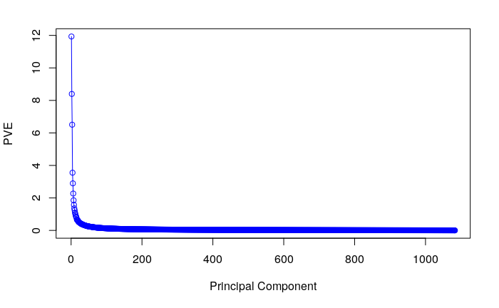

```r
pve<-100*PCA_BRCA$sdev^2/sum(PCA_BRCA$sdev^2)
plot(pve, type="o", ylab="PVE", xlab="Principal Component", col="blue")
```

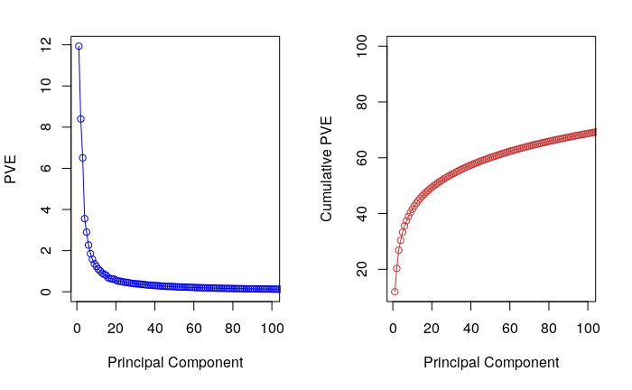

```r
par(mfrow=c(1,2))
plot(pve, type="o", ylab="PVE", xlab="Principal Component", xlim=c(1,100), col="blue")
plot(cumsum(pve), type="o", ylab="Cumulative PVE", xlab="Principal Component", xlim=c(1,100),col="brown3")
```

```r
print("PVE")
```

```
[1] "PVE"
```

```r
round(pve[1:10],2)
```

```
 [1] 11.93  8.40  6.51  3.55  2.90  2.27  1.85  1.57  1.36  1.24
```

```r
print("Cumulative PVE")
```

```
[1] "Cumulative PVE"
```

```r
round(cumsum(pve)[1:10],2)
```

```
 [1] 11.93 20.33 26.83 30.38 33.28 35.55 37.40 38.98 40.34 41.58
```

In contrast to the PSON PCA where the first two PCs account for 40% of the variance, the first two PCs for the TCGA brca analysis account for only 20% of the variance. However, for large microarray data sets, this is considered pretty good, and often PC1 and PC2 carry a fair amount of useful information.

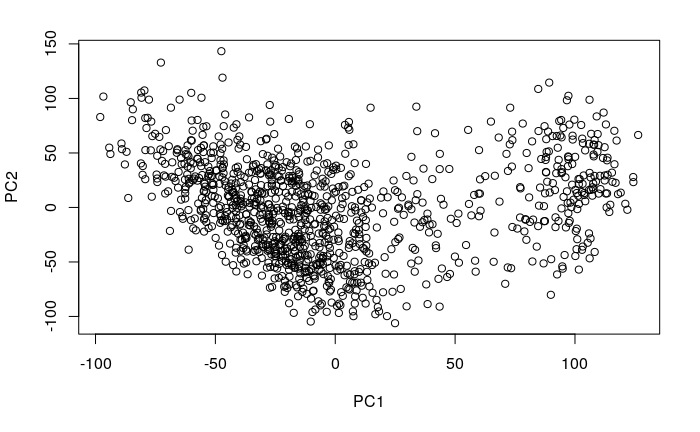

```r
plot(PCA_BRCA$x[,c(1,2)])
```

We see roughly two clusters. Do these have biologial meaning? What clinical information do we have on the TCGA brca samples?

```r
names(brca_clinical_df)
```

```
 [1] "bcr_patient_uuid"
 [2] "bcr_patient_barcode"
 [3] "acronym"
 [4] "gender"
 [5] "vital_status"
 [6] "days_to_birth"
 [7] "days_to_last_followup"
 [8] "days_to_initial_pathologic_diagnosis"
 [9] "age_at_initial_pathologic_diagnosis"
[10] "icd_10"
[11] "tissue_retrospective_collection_indicator"
[12] "icd_o_3_histology"
[13] "tissue_prospective_collection_indicator"
[14] "history_of_neoadjuvant_treatment"
[15] "icd_o_3_site"
```

[output cut: 30 more lines]

```r
brca_clinical_df$bcr_patient_barcode[1:5]
```

```
[1] "TCGA-3C-AAAU" "TCGA-3C-AALI" "TCGA-3C-AALJ" "TCGA-3C-AALK" "TCGA-4H-AAAK"
```

Ok, so we have quite a lot of information. Let’s consider estrogen receptor (ER) status. We considered this in the lecture for a different brca set. I am including lines to pull the progeterone receptor (PR) and the receptor tyrosine kinase erbB-2 (HER2) for your examination later.

```r
ER_status<-brca_clinical_df[,43]
PR_status<-brca_clinical_df[,40]
HER2_status<-brca_clinical_df[,44]
```

What values are encompassed by the receptor status clinical features?

```r
unique_status<-unique(ER_status)
for (i in 1:length(unique_status)){
  print(c(unique_status[i],length(ER_status[ER_status==unique_status[i]])))
}
```

```
[1] "Positive" "797"
[1] "Negative" "236"
[1] "[Not Evaluated]" "48"
[1] "Indeterminate" "2"
```

```r
unique_status<-unique(PR_status)
for (i in 1:length(unique_status)){
  print(c(unique_status[i],length(PR_status[PR_status==unique_status[i]])))
}
```

```
[1] "Positive" "690"
[1] "Negative" "340"
[1] "[Not Evaluated]" "49"
[1] "Indeterminate" "4"
```

```r
unique_status<-unique(HER2_status)
for (i in 1:length(unique_status)){
  print(c(unique_status[i],length(HER2_status[HER2_status==unique_status[i]])))
}
```

```
[1] "Negative" "555"
[1] "Positive" "161"
[1] "Indeterminate" "12"
[1] "Equivocal" "177"
[1] "[Not Evaluated]" "170"
[1] "[Not Available]" "8"
```

We color the samples in the PC1/PC2 project plot according to ER status.

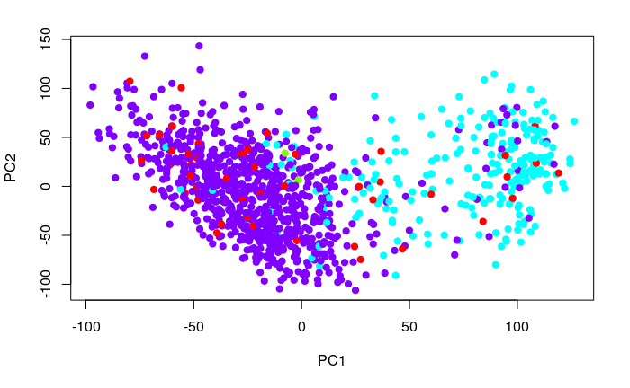

```r
plot(PCA_BRCA$x[,c(1,2)],col=csbc_Color(ER_status),pch=19)
```